# QTM 350 - Data Science Computing

Danilo Freire

danilo.freire@emory.edu

Emory University

# Hello, my friends! 😊

# Brief recap 📚

## Recap of last class and today’s plan

### Last time we learned how to:

- Connect SQL with Python with `psychopg2` and `sqlalchemy`
- Use many SQL commands, such as `CASE WHEN`, window functions, and string functions
- Use `pandas` to write SQL queries
- Fill missing data with `COALESCE`
- Pivot tables in PostgreSQL

### Today we will learn how to:

- See different types of join in SQL
- Use special joins, such as `CROSS JOIN` and `SELF JOIN`
- Merge tables by row with `UNION`, `INTERSECT`, and `EXCEPT`
- Use join conditions with `ON`, `USING`, and `NATURAL JOIN`
- Solve exercises to practice what we learned
- Let’s get started! 🚀

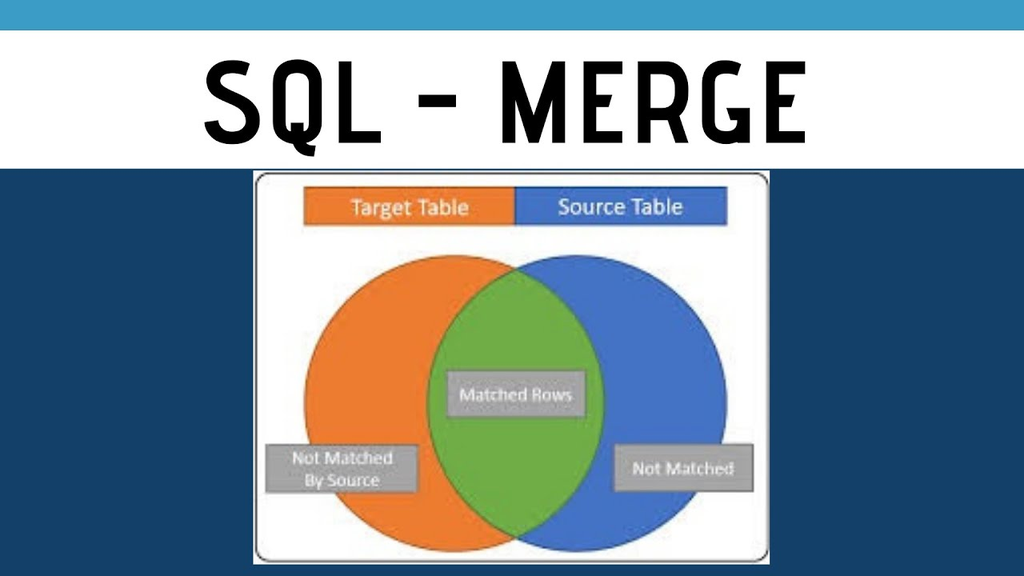

## An announcement 📢

[figure not shown]

## Another announcement 📢

### Final project instructions

- The instructions for the final project is now available on GitHub
- Please find it here: https://github.com/danilofreire/qtm350/blob/main/project/project-instructions.pdf
- The project is due on **December 9th, 2024**
- Groups of 3-4 students
- You will create a GitHub repository with a report based on World Bank data
- The report should be in Quarto, the data cleaning and descriptive statistics in SQL, and the data analysis and visualisation in Python
- QTM 531 students will also have to create a website with the report, as well as to write additional sections in the report
- Please let me know if you have any questions

# Basic joins 📊

## Primary and foreign keys

- As with many languages, you can merge two tables in SQL either by columns or by rows
- Each uses different methods, but the most common is the `JOIN` clause
- The `JOIN` clause is used to combine rows and columns from two or more tables based on a related column between them
- There are two types of keys, primary and foreign keys
- The primary key is a column that uniquely identifies each row in a table
  - It must contain a unique value for each row of the table and cannot contain `NULL` values. One table can have only one primary key
- A foreign key is a column that identifies a column in another table
  - It references the key of another table. One table can have multiple foreign keys, and they can be `NULL`

[figure not shown]

## Load the libraries and connect to the database

- Let’s load the libraries and connect to the database

```python
import pandas as pd
import psycopg2
from sqlalchemy import create_engine, text

# Connect to the database
engine = create_engine('postgresql+psycopg2://postgres:postgres@localhost:5432/postgres')
connection = engine.connect()
```

- Then let’s create two tables that we will use to test the `JOIN` clauses

```python
# Create the tables
connection.execute(text('''
DROP TABLE IF EXISTS players;
CREATE TABLE players (
    player_id SERIAL PRIMARY KEY,
    player_name VARCHAR(50) NOT NULL,
    goals INT NOT NULL,
    victories INT NOT NULL
);
'''))

connection.execute(text('''
DROP TABLE IF EXISTS teams;
CREATE TABLE teams (
    team_id SERIAL PRIMARY KEY,
    team_name VARCHAR(50) NOT NULL
);
'''))
connection.commit()
```

## Create the tables

- Now let’s insert some data into the tables
- Problems with the code below? Try to clean the database first (see how in this appendix), then create the connection and tables again

```python
# Insert data into the tables
connection.execute(text('''
INSERT INTO players (player_name, goals, victories) VALUES
('Messi', 10, 5),
('Vini Jr', 8, 4),
('Neymar', 6, 3),
('Mbappe', 5, 2),
('Lewandowski', 4, 1),
('Haaland', 5, 3);
'''))

connection.execute(text('''
INSERT INTO teams (team_name) VALUES
('Inter Miami'),
('Real Madrid'),
('Al Hilal'),
('Real Madrid'),
('Bayern');
'''))
connection.commit()
```

## Visualise the tables

- Let’s see our tables

```python
pd.read_sql('SELECT * FROM players', connection)
```

|  | player_id | player_name | goals | victories |
| --- | --- | --- | --- | --- |
| 0 | 1 | Messi | 10 | 5 |
| 1 | 2 | Vini Jr | 8 | 4 |
| 2 | 3 | Neymar | 6 | 3 |
| 3 | 4 | Mbappe | 5 | 2 |
| 4 | 5 | Lewandowski | 4 | 1 |
| 5 | 6 | Haaland | 5 | 3 |

```python
pd.read_sql('SELECT * FROM teams', connection)
```

|  | team_id | team_name |
| --- | --- | --- |
| 0 | 1 | Inter Miami |
| 1 | 2 | Real Madrid |
| 2 | 3 | Al Hilal |
| 3 | 4 | Real Madrid |
| 4 | 5 | Bayern |

## Types of joins

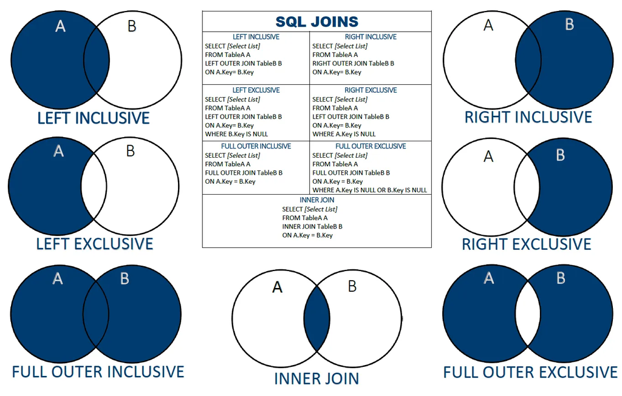

## Inner join

- The `INNER JOIN` returns only the records where there is a match between both tables (intersection)
- If there’s no match for a record in either table, that record will be excluded from the results
- Each match creates a new row in the result set that combines columns from both tables
- The matching condition is specified in the `ON` clause (e.g., `ON table1.id = table2.id`)
- It is commonly used to combine related data, like the ones we have in the `players` and `teams` tables
- The syntax is as follows:
- `SELECT columns FROM table1 INNER JOIN table2 ON table1.column = table2.column`
- Note that Haaland is not in the `teams` table, so he will not appear in the result set

```python
pd.read_sql('''
SELECT players.player_name, teams.team_name, players.goals, players.victories
FROM players
INNER JOIN teams
ON players.player_id = teams.team_id;
''', connection)
```

|  | player_name | team_name | goals | victories |
| --- | --- | --- | --- | --- |
| 0 | Messi | Inter Miami | 10 | 5 |
| 1 | Vini Jr | Real Madrid | 8 | 4 |
| 2 | Neymar | Al Hilal | 6 | 3 |
| 3 | Mbappe | Real Madrid | 5 | 2 |
| 4 | Lewandowski | Bayern | 4 | 1 |

## Left join

- The `LEFT JOIN` returns all records from the left table (first table) and the matched records from the right table (second table)
- The result is `NULL` from the right side if there is no match
- This is perhaps the most common type of join, as it keeps the data from the table we are usually interested in
- The syntax is as follows (pretty much the same as `INNER JOIN`):
- `SELECT columns FROM table1 LEFT JOIN table2 ON table1.column = table2.column`
- Note that Haaland is here because he is in the `players` table, even though he is not in the `teams` table

```python
pd.read_sql('''
SELECT players.player_name, teams.team_name, players.goals
FROM players
LEFT JOIN teams
ON players.player_id = teams.team_id;
''', connection)
```

|  | player_name | team_name | goals |
| --- | --- | --- | --- |
| 0 | Messi | Inter Miami | 10 |
| 1 | Vini Jr | Real Madrid | 8 |
| 2 | Neymar | Al Hilal | 6 |
| 3 | Mbappe | Real Madrid | 5 |
| 4 | Lewandowski | Bayern | 4 |
| 5 | Haaland | None | 5 |

## Right join

- The `RIGHT JOIN` returns all records from the right table (second table) and the matched records from the left table (first table)
- The result is `NULL` from the left side if there is no match
- As you have probably guessed, this is the opposite of the `LEFT JOIN` (and less common)
- The syntax is as follows (you have probably guessed it by now 😄):
- `SELECT columns FROM table1 RIGHT JOIN table2 ON table1.column = table2.column`

```python
pd.read_sql('''
SELECT players.player_name, teams.team_name, players.goals
FROM players
RIGHT JOIN teams
ON players.player_id = teams.team_id;
''', connection)
```

|  | player_name | team_name | goals |
| --- | --- | --- | --- |
| 0 | Messi | Inter Miami | 10 |
| 1 | Vini Jr | Real Madrid | 8 |
| 2 | Neymar | Al Hilal | 6 |
| 3 | Mbappe | Real Madrid | 5 |
| 4 | Lewandowski | Bayern | 4 |

## Full outer join

- The `FULL OUTER JOIN` returns all records when there is a match in either left (first) or right (second) table
- It returns `NULL` values when there is no match
- In my experience, this is the least common type of join
- Why? Because it returns all the data from both tables, which can be a lot and not very useful
- It also overloads the database, as it has to compare all the records from both tables

```python
pd.read_sql('''
SELECT players.player_name, teams.team_name, players.goals
FROM players
FULL OUTER JOIN teams
ON players.player_id = teams.team_id;
''', connection)
```

|  | player_name | team_name | goals |
| --- | --- | --- | --- |
| 0 | Messi | Inter Miami | 10 |
| 1 | Vini Jr | Real Madrid | 8 |
| 2 | Neymar | Al Hilal | 6 |
| 3 | Mbappe | Real Madrid | 5 |
| 4 | Lewandowski | Bayern | 4 |
| 5 | Haaland | None | 5 |

## Try it yourself! 🧠

- Let’s create two new tables and insert some data into them

```python
# Create the tables and insert data
connection.execute(text('''
DROP TABLE IF EXISTS products CASCADE;
CREATE TABLE products (
    product_id SERIAL PRIMARY KEY,
    product_name VARCHAR(100) NOT NULL,
    price DECIMAL(10,2) -- 10 digits, 2 decimal places for money
);

-- Insert products (notice some won't have reviews)
INSERT INTO products (product_name, price) VALUES
    ('Coffee Maker', 99.99),
    ('Toaster', 29.99),
    ('Blender', 79.99),
    ('Microwave', 149.99),
    ('Air Fryer', 89.99);

DROP TABLE IF EXISTS reviews CASCADE;
CREATE TABLE reviews (
    review_id SERIAL PRIMARY KEY,
    product_id INT,
    rating INT CHECK (rating BETWEEN 1 AND 5),
    comment TEXT,
    FOREIGN KEY (product_id) REFERENCES products(product_id)
);

-- Insert reviews (only for some products)
INSERT INTO reviews (product_id, rating, comment) VALUES
    (1, 5, 'Great coffee maker!'),
    (1, 4, 'Good but expensive'),
    (2, 3, 'Average toaster'),
    (3, 5, 'Best blender ever');
'''))
connection.commit()
```

## Try it yourself! 🧠

# Special joins 🌟

## Cross join

```python
pd.read_sql('''
SELECT players.player_name, teams.team_name
FROM players
CROSS JOIN teams
ORDER BY players.player_id;
''', connection)
```

|  | player_name | team_name |
| --- | --- | --- |
| 0 | Messi | Inter Miami |
| 1 | Messi | Real Madrid |
| 2 | Messi | Al Hilal |
| 3 | Messi | Real Madrid |
| 4 | Messi | Bayern |
| 5 | Vini Jr | Inter Miami |
| 6 | Vini Jr | Real Madrid |
| 7 | Vini Jr | Al Hilal |
| 8 | Vini Jr | Real Madrid |
| 9 | Vini Jr | Bayern |
| 10 | Neymar | Inter Miami |
| 11 | Neymar | Real Madrid |
| 12 | Neymar | Al Hilal |
| 13 | Neymar | Real Madrid |
| 14 | Neymar | Bayern |
| 15 | Mbappe | Inter Miami |
| 16 | Mbappe | Real Madrid |
| 17 | Mbappe | Al Hilal |
| 18 | Mbappe | Real Madrid |
| 19 | Mbappe | Bayern |
| 20 | Lewandowski | Inter Miami |
| 21 | Lewandowski | Real Madrid |
| 22 | Lewandowski | Al Hilal |
| 23 | Lewandowski | Real Madrid |
| 24 | Lewandowski | Bayern |
| 25 | Haaland | Inter Miami |
| 26 | Haaland | Real Madrid |
| 27 | Haaland | Al Hilal |
| 28 | Haaland | Real Madrid |
| 29 | Haaland | Bayern |

## Cross join

- Sometimes it is useful to generate all possible combinations of two tables

```python
# Drop and recreate tables
connection.execute(text('''
DROP TABLE IF EXISTS colors CASCADE;
CREATE TABLE colors (color_name VARCHAR(20));
DROP TABLE IF EXISTS sizes CASCADE;
CREATE TABLE sizes (size_code VARCHAR(5));
INSERT INTO colors VALUES ('Black'), ('Red');
INSERT INTO sizes VALUES ('S'), ('M');
'''))

pd.read_sql(text('''
SELECT
    colors.color_name,
    sizes.size_code,
    CONCAT(colors.color_name, ' - ', sizes.size_code) as t_shirt
FROM colors
CROSS JOIN sizes
ORDER BY colors.color_name, sizes.size_code DESC;
'''), connection)
```

|  | color_name | size_code | t_shirt |
| --- | --- | --- | --- |
| 0 | Black | S | Black - S |
| 1 | Black | M | Black - M |
| 2 | Red | S | Red - S |
| 3 | Red | M | Red - M |

## Self join

- A self join is a regular join, but the table is joined with itself (!) 🤯
- It may not be immediately apparent how this could be useful, but it actually has many applications
- Often, tables describe entities that can fulfill multiple roles in relationship to one another
- For instance, if you have a table of `people`, each row could contain a `mother` column that reference other people in the table with the same `person_id`
- A self join would allow you to stitch these different rows together by joining a second instance of the table to the first where these values match
- Since self joins reference the same table twice, table aliases are required to disambiguate the references
- You could join the two instances of the `people` table using the aliases `people AS children` and `people AS mothers`
- That way, you can specify which instance of the table you are referring to when defining join conditions
- The syntax is as follows: `SELECT columns FROM table1 AS alias1 JOIN table1 AS alias2 ON alias1.column = alias2.column`

## Self join

- Let see an example

```python
connection.execute(text('''
DROP TABLE IF EXISTS family CASCADE;
CREATE TABLE family (
    person_id SERIAL PRIMARY KEY,
    name VARCHAR(50),
    mother_id INT
);

INSERT INTO family (name, mother_id) VALUES
    ('Emma', NULL), -- grandmother
    ('Sarah', 1),   -- Emma's daughter
    ('Lisa', 1),    -- Emma's daughter
    ('Tom', 2),     -- Sarah's son
    ('Alice', 2);   -- Sarah's daughter
'''))

pd.read_sql('''
SELECT
    children.name as child,
    mothers.name as mother
FROM family children
JOIN family mothers ON children.mother_id = mothers.person_id
ORDER BY mothers.name;
''', connection)
```

|  | child | mother |
| --- | --- | --- |
| 0 | Sarah | Emma |
| 1 | Lisa | Emma |
| 2 | Tom | Sarah |
| 3 | Alice | Sarah |

## Self join

- Let see another example
- Here we want to calculate the difference in goals between players in the `players` table

```python
pd.read_sql('''
SELECT
    p1.player_name,
    p1.goals,
    p2.player_name as compared_to,
    p2.goals as their_goals,
    p1.goals - p2.goals as difference
FROM players p1
JOIN players p2
ON p1.player_id < p2.player_id
ORDER BY difference DESC;
''', connection)
```

|  | player_name | goals | compared_to | their_goals | difference |
| --- | --- | --- | --- | --- | --- |
| 0 | Messi | 10 | Lewandowski | 4 | 6 |
| 1 | Messi | 10 | Mbappe | 5 | 5 |
| 2 | Messi | 10 | Haaland | 5 | 5 |
| 3 | Vini Jr | 8 | Lewandowski | 4 | 4 |
| 4 | Messi | 10 | Neymar | 6 | 4 |
| 5 | Vini Jr | 8 | Haaland | 5 | 3 |
| 6 | Vini Jr | 8 | Mbappe | 5 | 3 |
| 7 | Messi | 10 | Vini Jr | 8 | 2 |
| 8 | Vini Jr | 8 | Neymar | 6 | 2 |
| 9 | Neymar | 6 | Lewandowski | 4 | 2 |
| 10 | Neymar | 6 | Haaland | 5 | 1 |
| 11 | Mbappe | 5 | Lewandowski | 4 | 1 |
| 12 | Neymar | 6 | Mbappe | 5 | 1 |
| 13 | Mbappe | 5 | Haaland | 5 | 0 |
| 14 | Lewandowski | 4 | Haaland | 5 | -1 |

## Try it yourself! 🧠

- Write a SQL query that:
  - Uses a self join on the players table to compare players’ `victories`
- Shows for each pair of players:
  - First player’s name and victories
  - Second player’s name and victories
  - The ratio of their victories (rounded to 2 decimal places)
- Requirements:
- Use `CAST AS NUMERIC` to handle decimal division (`ROUND(CAST(p1.victories AS NUMERIC) / CAST(p2.victories AS NUMERIC), 2) as victories_ratio`)
- Avoid duplicate comparisons using `player_id < player_id`
- Prevent division by zero by adding `WHERE p2.victories > 0`
- Order results by first player’s ID
- Appendix 02

# Join conditions 🧩

## Join conditions

- The most standard way of defining the conditions for table joins is with the `ON` clause
- `ON` uses an equals sign to specify the exact columns from each table that will be compared
- PostgreSQL uses the provided columns to stitch together the rows from each table
- `ON` is verbose, but also very flexible, as it allows you to specify any condition you want

```python
pd.read_sql('''
SELECT players.player_name, teams.team_name, players.goals
FROM players
JOIN teams
ON players.player_id = teams.team_id;
''', connection)
```

|  | player_name | team_name | goals |
| --- | --- | --- | --- |
| 0 | Messi | Inter Miami | 10 |
| 1 | Vini Jr | Real Madrid | 8 |
| 2 | Neymar | Al Hilal | 6 |
| 3 | Mbappe | Real Madrid | 5 |
| 4 | Lewandowski | Bayern | 4 |

- You can also use the `USING` clause to specify the columns that will be used to join the tables
- `USING` is a bit more concise than `ON`, as it only requires the column names
- Let’s create a new column `player_id` in the `teams` table to demonstrate how `USING` works

```python
# First add team_id to players if not exists
connection.execute(text('''
ALTER TABLE teams ADD COLUMN IF NOT EXISTS player_id SERIAL;
'''))

# Show joined data using USING clause
pd.read_sql('''
SELECT player_name, team_name, goals
FROM players
JOIN teams USING (player_id);
''', connection)
```

|  | player_name | team_name | goals |
| --- | --- | --- | --- |
| 0 | Messi | Inter Miami | 10 |
| 1 | Vini Jr | Real Madrid | 8 |
| 2 | Neymar | Al Hilal | 6 |
| 3 | Mbappe | Real Madrid | 5 |
| 4 | Lewandowski | Bayern | 4 |

## Natural join

- This is a cool feature of PostgreSQL!
- A `NATURAL JOIN` does not specify any columns to be matched
- Instead, PostgreSQL will automatically join the tables based on all columns that have matching columns in each database

```python
pd.read_sql('''
SELECT players.player_name, teams.team_name, players.goals
FROM players
NATURAL JOIN teams;
''', connection)
```

|  | player_name | team_name | goals |
| --- | --- | --- | --- |
| 0 | Messi | Inter Miami | 10 |
| 1 | Vini Jr | Real Madrid | 8 |
| 2 | Neymar | Al Hilal | 6 |
| 3 | Mbappe | Real Madrid | 5 |
| 4 | Lewandowski | Bayern | 4 |

# Merge tables by row 🧩

## Union

- The `UNION` operator is used to combine the result sets of two or more `SELECT` statements
- It removes duplicate rows between the various `SELECT` statements
- The columns in each `SELECT` statement must be in the same order, with the same data types

```python
pd.read_sql('''
SELECT player_name, goals FROM players
UNION
SELECT team_name, NULL FROM teams
ORDER BY player_name;
''', connection)
```

|  | player_name | goals |
| --- | --- | --- |
| 0 | Al Hilal | NaN |
| 1 | Bayern | NaN |
| 2 | Haaland | 5.0 |
| 3 | Inter Miami | NaN |
| 4 | Lewandowski | 4.0 |
| 5 | Mbappe | 5.0 |
| 6 | Messi | 10.0 |
| 7 | Neymar | 6.0 |
| 8 | Real Madrid | NaN |
| 9 | Vini Jr | 8.0 |

## Union all and intersect

- Similar to `UNION`, `UNION ALL` also merges tables by rows
- Unlike `UNION`, `UNION ALL` retains the duplicate records of both the tables

```python
pd.read_sql('''
INSERT INTO players (player_name, goals, victories) VALUES ('Real Madrid', 0, 0);
SELECT player_name FROM players
UNION ALL
SELECT team_name FROM teams;
''', connection)
```

|  | player_name |
| --- | --- |
| 0 | Messi |
| 1 | Vini Jr |
| 2 | Neymar |
| 3 | Mbappe |
| 4 | Lewandowski |
| 5 | Haaland |
| 6 | Real Madrid |
| 7 | Inter Miami |
| 8 | Real Madrid |
| 9 | Al Hilal |
| 10 | Real Madrid |
| 11 | Bayern |

- The `INTERSECT` operator is used to return the common rows between two queries

```python
pd.read_sql('''
INSERT INTO players (player_name, goals, victories) VALUES ('Real Madrid', 0, 0);
SELECT player_name FROM players
INTERSECT
SELECT team_name FROM teams;
''', connection)
```

|  | player_name |
| --- | --- |
| 0 | Real Madrid |

## Except

- `EXCEPT` returns the records from the first table (left table) which are not present in the second table (right table)

```python
pd.read_sql('''
INSERT INTO players (player_name, goals, victories) VALUES ('Real Madrid', 0, 0);
SELECT player_name FROM players
EXCEPT
SELECT team_name FROM teams;
''', connection)
```

|  | player_name |
| --- | --- |
| 0 | Mbappe |
| 1 | Neymar |
| 2 | Lewandowski |
| 3 | Messi |
| 4 | Vini Jr |
| 5 | Haaland |

# Merge operator

## Merge

- PostgreSQL 15 introduced the `MERGE` operator, which allows you to perform an `INSERT`, `UPDATE`, or `DELETE` operation in a single statement
- It is extremely flexible, easy to read, and efficient. More info [here](https://www.postgresql.org/docs/current/sql-merge.html)
- It is better to see it with an example

```python
connection.execute(text('''
ALTER TABLE teams ADD COLUMN IF NOT EXISTS player_id SERIAL;
ALTER TABLE teams ADD COLUMN IF NOT EXISTS team_player VARCHAR(100);

MERGE INTO teams AS t
USING players AS p
ON t.player_id = p.player_id
WHEN MATCHED THEN
    UPDATE SET team_player = (p.player_name || ' - ' || t.team_name)
WHEN NOT MATCHED THEN
    INSERT (team_name) VALUES (p.player_name);
'''))

pd.read_sql('SELECT * FROM teams', connection)
```

|  | team_id | team_name | player_id | team_player |
| --- | --- | --- | --- | --- |
| 0 | 1 | Inter Miami | 1 | Messi - Inter Miami |
| 1 | 2 | Real Madrid | 2 | Vini Jr - Real Madrid |
| 2 | 3 | Al Hilal | 3 | Neymar - Al Hilal |
| 3 | 4 | Real Madrid | 4 | Mbappe - Real Madrid |
| 4 | 5 | Bayern | 5 | Lewandowski - Bayern |
| 5 | 6 | Haaland | 6 | None |
| 6 | 7 | Real Madrid | 7 | None |
| 7 | 8 | Real Madrid | 8 | None |
| 8 | 9 | Real Madrid | 9 | None |

# Conclusion 📖

## Conclusion

- Today we learned about different types of joins in SQL
- We also learned about special joins, such as `CROSS JOIN` and `SELF JOIN`
- We saw how to merge tables by row with `UNION`, `INTERSECT`, and `EXCEPT`
- We also learned about join conditions with `ON`, `USING`, and `NATURAL JOIN`
- And we saw the new `MERGE` operator in PostgreSQL 15+ 🚀

# And that’s all for today! 🎉

# Thank you and have a great rest of your day! 🙏

## Appendix 01

- Here is the solution to the exercise

```python
print("INNER JOIN Results:")
print(pd.read_sql('''
    SELECT p.product_name, r.rating, r.comment
    FROM products p
    INNER JOIN reviews r ON p.product_id = r.product_id
    ORDER BY p.product_id;
''', connection))
```

```
INNER JOIN Results:
   product_name  rating              comment
0  Coffee Maker       5  Great coffee maker!
1  Coffee Maker       4   Good but expensive
2       Toaster       3      Average toaster
3       Blender       5    Best blender ever
```

```python
print("\nLEFT JOIN Results:")
print(pd.read_sql('''
    SELECT p.product_name, r.rating, r.comment
    FROM products p
    LEFT JOIN reviews r ON p.product_id = r.product_id
    ORDER BY p.product_id;
''', connection))
```

```
LEFT JOIN Results:
   product_name  rating              comment
0  Coffee Maker     5.0  Great coffee maker!
1  Coffee Maker     4.0   Good but expensive
2       Toaster     3.0      Average toaster
3       Blender     5.0    Best blender ever
4     Microwave     NaN                 None
5     Air Fryer     NaN                 None
```

Back to exercise

## Appendix 02

```python
pd.read_sql('''
SELECT p1.player_name, p1.victories, p2.player_name, p2.victories,
    ROUND(CAST(p1.victories AS NUMERIC) / CAST(p2.victories AS NUMERIC), 2) AS victories_ratio
FROM players p1
JOIN players p2
ON p1.player_id < p2.player_id
WHERE p2.victories > 0
ORDER BY p1.player_id;
''', connection)
```

|  | player_name | victories | player_name | victories | victories_ratio |
| --- | --- | --- | --- | --- | --- |
| 0 | Messi | 5 | Vini Jr | 4 | 1.25 |
| 1 | Messi | 5 | Neymar | 3 | 1.67 |
| 2 | Messi | 5 | Mbappe | 2 | 2.50 |
| 3 | Messi | 5 | Lewandowski | 1 | 5.00 |
| 4 | Messi | 5 | Haaland | 3 | 1.67 |
| 5 | Vini Jr | 4 | Neymar | 3 | 1.33 |
| 6 | Vini Jr | 4 | Mbappe | 2 | 2.00 |
| 7 | Vini Jr | 4 | Lewandowski | 1 | 4.00 |
| 8 | Vini Jr | 4 | Haaland | 3 | 1.33 |
| 9 | Neymar | 3 | Mbappe | 2 | 1.50 |
| 10 | Neymar | 3 | Lewandowski | 1 | 3.00 |
| 11 | Neymar | 3 | Haaland | 3 | 1.00 |
| 12 | Mbappe | 2 | Lewandowski | 1 | 2.00 |
| 13 | Mbappe | 2 | Haaland | 3 | 0.67 |
| 14 | Lewandowski | 1 | Haaland | 3 | 0.33 |

Back to exercise

## Appendix 05

### Cleaning all tables

- I have encountered some issues with `psycopg2` when trying to drop tables
- So I created a function to clean all tables in the database
- If you have a similar issue, you can use the function below
- Replace the default values with your database name, user, and password

```python
from sqlalchemy import create_engine, text, inspect
import time

engine = create_engine('postgresql+psycopg2://postgres:postgres@localhost:5432/postgres', future=True)
connection = engine.connect()

def clean_database(engine):
    with engine.connect() as conn:
        try:
            # Get inspector to check existing tables
            inspector = inspect(engine)
            existing_tables = inspector.get_table_names()

            if not existing_tables:
                print("No tables found in database")
                return

            print(f"Found {len(existing_tables)} tables: {existing_tables}")

            # Kill other connections
            conn.execute(text("""
                SELECT pg_terminate_backend(pid)
                FROM pg_stat_activity
                WHERE pid <> pg_backend_pid()
                AND datname = current_database()
            """))

            conn.execute(text("ROLLBACK"))
            conn.execute(text("SET statement_timeout = '30s'"))

            # Only drop tables that exist
            for table in existing_tables:
                try:
                    conn.execute(text(f"DROP TABLE IF EXISTS {table} CASCADE"))
                    print(f"Dropped {table}")
                    conn.commit()
                    time.sleep(1)
                except Exception as e:
                    print(f"Error with {table}: {str(e)}")
                    conn.execute(text("ROLLBACK"))

        except Exception as e:
            print(f"Fatal error: {str(e)}")
            conn.execute(text("ROLLBACK"))

# Execute
clean_database(engine)
```

Back to the lecture

[SQL Joins](https://raw.githack.com/danilofreire/qtm350/main/lectures/lecture-19/10-sql-tables.html)